# ChromSCape Guide

Pacôme Prompsy, Pia Kirchmeier & Céline Vallot

5/9/2020

# Installation

**ChromSCape** requires R version 3.5 or higher (does not work on R 4.0 yet). To install **ChromSCape**, open **R** or **Rstudio** and copy the following commands :

```r
if (!requireNamespace("devtools", quietly = TRUE)){
  install.packages("devtools")
}
devtools::install_github("vallotlab/ChromSCape")
```

## Launching the application

To launch the application simply run:

```r
library(ChromSCape)
ChromSCape::launchApp()
```

# What is ChromSCape ?

**ChromSCape** - Single-Cell Chromatin Landscape profiling - is a ready-to-launch user-friendly **Shiny** application for analysis of single-cell epigenomic datasets (scChIP-seq, scATAC-seq…). ChromSCape is used to reveal heterogeneity of chromatin landscapes within single-cell of one or more samples using dimensionality reduction & unsupervised consensus clustering. The user can then interrogate the biological difference of each epigenomic subpopulation by running differential analysis & gene set enrichment analysis.  
Various existing technologies allow to produce single-cell genome-wide epigenomic datasets :

- scChIP-seq (Grosselin et al., 2019) CUT&TAG (Kaya-Okur et al., 2019), scChIL-seq (Harada et al., 2019), scChIC-seq (Ku et al.,) are technologies that isolate DNA sequences attached to histones with specific marks (H3K27me3, H3K4me3) or transcription factors (RNA Polymerase 2,…) in single-cells
- scATAC-seq (Buenorostro et al., 2015), sciATAC-seq (Cusanovitch et al., 2016) are technologies that allows to asses regions of open chromatin in single-cells

[figure not shown]

**ChromSCape Overview:** The application takes as input various single-cell format and let the user filter & cluster cells, run differential analysis & gene set enrichment analysis between epigenomic subpopulations, in an unsupervised manner.

# Step-by-step analysis of single-cell epigenomic data

## 0. Input files (before launching ChromSCape)

After sequencing a single-cell epigenomic experiment, the raw sequencing files (.fastq) are demultiplexed, aligned against a reference genome to output different kind of data depending on the technology.  
ChromSCape allows user to input a variety of different format. Depending on the output of the data-engineering/pre-processing pipeline used, the signal can be already *summarized into features* (**Count matrix**, **Peak-Index-Barcode** files) or stored directly in *raw format* (**single-cell BAM** or **single-cell BED** files).

Anyhow the format, ChromSCape needs signal to be summarized into features. If inputting *raw signal* (**scBAM** or **scBED**), the application lets user summarize signal of each cells into various features:

- **Genomic features** (extended region around TSS of genes, enhancers)
- **Peaks** called on bulk or single-cell signal (BED file must be provided by the user)
- **Genomic bins** (windows of constant length, e.g. 100kbp, 50kbp, 5kbp…)

Note that summarizing will take longer if using BAM files than BED files, and if the number of features is important (e.g. 5kbp bins, enhancers…).

### Count matrices files

Each sample should be contained into single-cell count matrix (features x cells) in tab-separated format (extension .txt or .tsv) or comma-separated format (.csv). The first column is genomic location in standard format (chr:start-end) and the next columns are reads counted in each cells in the corresponding genomic feature. Note that the first entry (row 1, column 1) must be empty. All files should be placed in the same folder.

An example of such dataset is availablefor H3K27me3 mouse scChIP-seq of paired PDX samples at: [PDX mouse cells H3K27me3 scChIP-seq matrices](https://ndownloader.figshare.com/files/22629317).

```r
    BC969404    BC893525    BC239068    BC073314
chr10:0-50000   0   0   0   0
chr10:50000-100000  0   0   0   0
chr10:100000-150000 0   0   0   0
...
```

### Peak-Index-Barcode files

This format regroups three files containing signal of all samples of one or multiple experiment:

- The **barcode file** contains one cell barcode per line and finish by ’_barcode.txt’ :

```r
sample1_BC969404
sample1_BC893525
sample1_BC239068
sample2_BC073314
...
```

- The **peak file** contains feature location (usually peaks) must be in BED format and finish by ’_peaks.bed’:

```r
chr3    197959001   197961500
chr3    198080001   198081500
chr4    53001   55500
...
```

- The **index file** contains indexes of non-zero signal and finish by ’_indexes.txt’, the first column is the index of peaks, the second column contains barcode index, the last column contains the signal:

```r
459 1   1
461 1   1
556 1   2
...
```

### Single-cell BAM or BED files

Each BAM or BED (.bed or .bed.gz) file must be grouping signal of a single-cell, and all files must be placed in the same folder. The signal will be summarized into either bins, peaks, or around gene TSS depending on user choice.

An example of such dataset is publicly available for H3K27me3 single-cell CUT&TAG (Kaya-Okur et al., 2019) K562 and H1 cells at: [K562 H3K27me3 cells](https://www.ncbi.nlm.nih.gov/geo/download/?acc=GSE124680&format=file) and [K562 + H1 H3K27me3 cells](https://www.ncbi.nlm.nih.gov/geo/download/?acc=GSE129119&format=file). All files need to be placed in the same folders, the BED files do not need to be unzipped.

### Alignment BAM files for Peak Calling (**optional**)

For the optional step of Peak Calling on cluster of cells found de novo, users have to input one BAM file per sample, placed in the same folder. The barcode information of each read should be contained in a specific tag (XB, CB..) and correspond to the column names of the corresponding count matrix.

```r
samtools view example_matrix.bam | head
NS500388:436:HNG5VAFXX:2:21311:26430:3816   89  chr10   3102405 255 51M *   0   0   CTTGGTGTCTAGTGGATCTGCTGCAGTCTTCTGTTGTCAGTGCTAAATCAC EEEEE/E6EEEAEEEEEEEEEEEEEEEEEEEEEEEEEEEEEEEEEEAAAAA NH:i:1  HI:i:1  AS:i:50 nM:i:0  XS:i:2147483647 XD:Z:GATGACAAAG XB:Z:BC969404
...
```

## 1. Create & import a dataset

Once you have launched the application, you arrive on the “**Select & Import**”. Here you can selet an output directory, where your analyses will be saved. ChromSCape will automatically save the folder’s location so that you don’t have to select it each time you connect.

You must then name your analysis. The name shouldn’t contain special characters (except ’_‘). Choose either the Human (hg38) or Mouse (mm10) genome. This is used to annotate your features with the closest genes TSS for the Gene Set Analysis. Browse your computer for one or multiple matrices that will be analyzed together. To select multiple matrices, they must be placed in the same folder and then the user can select multiples matrices with (Shift + Click) or (Ctrl + Click).  
Finally, clicking on’**Create Analysis**’ will create an analysis & import the count matrices in this analysis. This will create a folder named ‘*ChromSCape_analyses*’ in the output directory you specified, inside which another folder ‘Your_analysis_name’ is nested. If you create another analysis, it will also be created under ‘*ChromSCape_analyses*’. If you already created an analysis in a previous section, selecting the same output directory as you chose in the previous session will enable you to load your analysis.

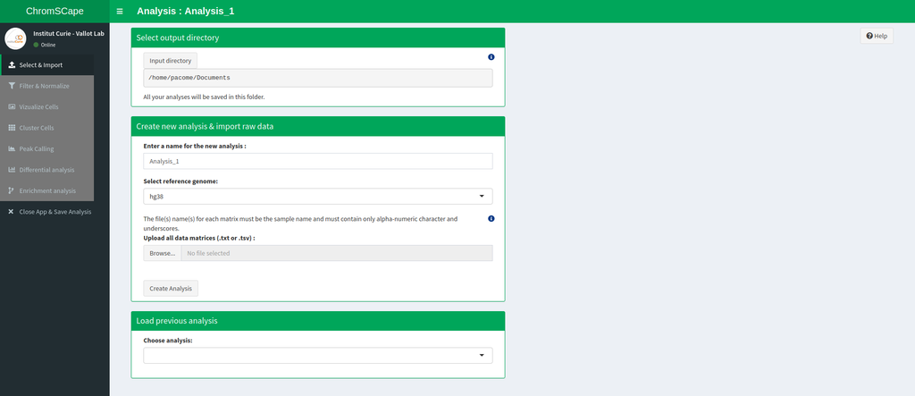

**Select & Import Tab:** Select an output directory, Create an analysis or load previous analyses, import count matrix into your new analysis.

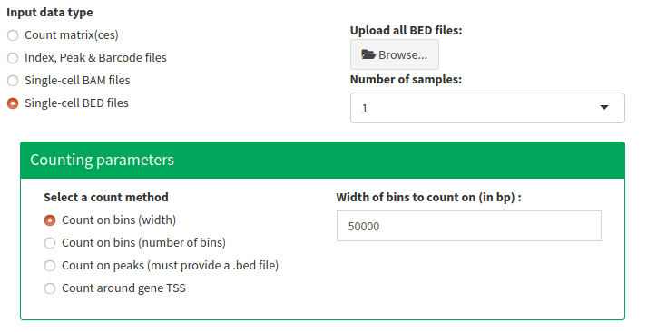

**Format Selection:** Select an type of format input, and eventually a type of feature to summarize signal.

## 2. Filter, Normalize & Reduce Dimensionality

[figure not shown]

**Filter, Normalize & Reduce Tab:** Adjust paramters to filter out low covered cells & features, as well as too highly covered cells that might be potential doublets. Normalize & Reduce dimensionality using PCA.

## 3. Visualize cells in reduced dimensions

[figure not shown]

**Visualize Cells:** Visualize cells in reduced dimensions: PCA, UMAP & TSNE. Color cells by sample, batch, or total count to make sure cells are not separating due to library size only.

## 4. Cluster cells

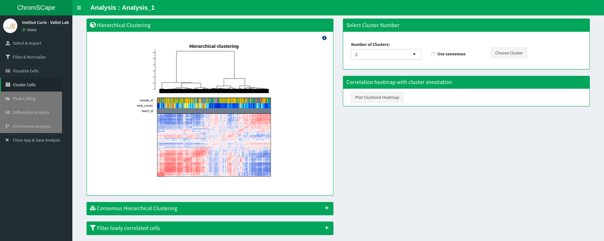

**Cluster Cells:** Choose a number of cluster if you have clear clusters of cells, or run consensus clustering to test multiple clustering and find the optimal cluster number. Optionally filter out lowly correlated cells that might impact the clustering performance.

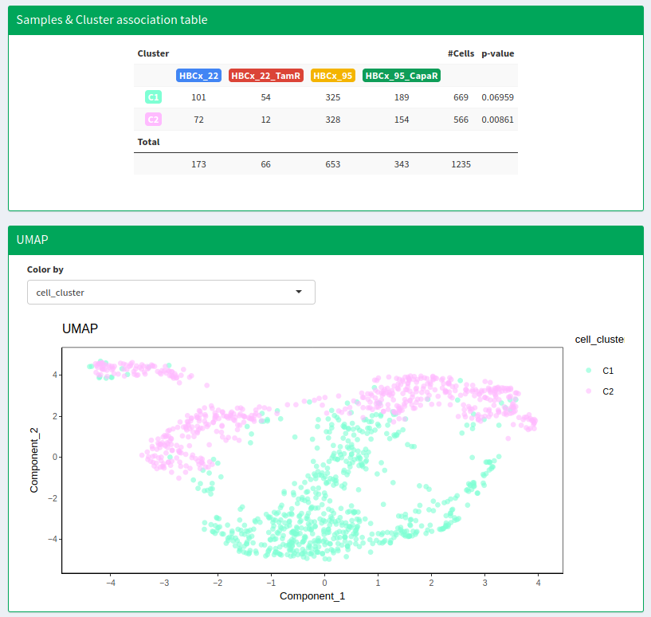

**Cluster Cells - results:** Association of cells to each cluster in a table & cluster visualization with UMAP.

## 5. Peak Calling to refine bins to gene annotation

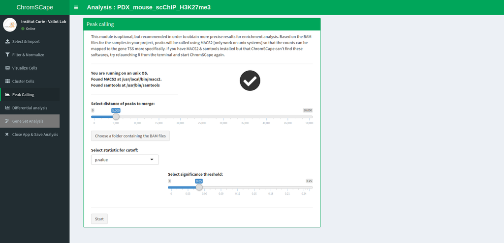

**Peak Calling to refine bins to gene annotation:** Call peaks on ‘pseudo-bulk’ cell clusters, and refine bins to genes annotation.

## 6. Differential Analysis

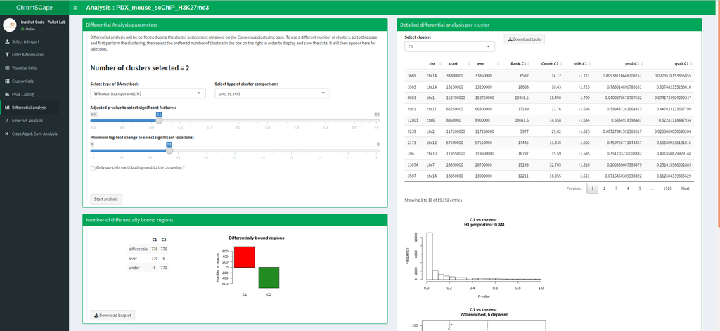

**Differential Analysis:** Identify most differential features between the various cell clusters

## 7. Gene Sets Analysis

[figure not shown]

**Gene Set Analysis:** Look for pathways activated or depleted in most differential regions between clusters

## FAQ

- **Error after deleting or moving files from ChromSCape_analysis ?**

Try remove cookies from the browser you are using, and start again selecting a different output folder.